# Week 7 Homework

## 7.1.5 Exercise

```r
W1 <- weightit(as.formula(trt_form_quad),
               method = "ps", ## propensity score
               estimand = "ATT", ## what we're looking for
               data = d)
summary(W1)
```

```
                 Summary of weights

- Weight ranges:

        Min                                   Max
treated   1 ||                             1.0000
control   0 |---------------------------| 83.9742

- Units with the 5 most extreme weights by group:

            2218    2217    2216    2215    2214
 treated       1       1       1       1       1
            1485    1484    1478      56    1521
 control 22.7435 22.7435 27.3148 48.3254 83.9742

- Weight statistics:

        Coef of Var   MAD Entropy # Zeros
treated       0.000 0.000  -0.000       0
control      12.211 1.732   3.841       0

- Effective Sample Sizes:

           Control Treated
Unweighted 2213.       297
Weighted     14.75     297
```

```r
# estimating of ATT
W1_att_mod <- lm(re78 ~ treat,
                 data = d,
                 weights = W1$weights)
tidy(W1_att_mod, conf.int = TRUE)
```

```
# A tibble: 2 × 7
  term        estimate std.error statistic   p.value conf.low conf.high
  <chr>          <dbl>     <dbl>     <dbl>     <dbl>    <dbl>     <dbl>
1 (Intercept)     4.84     0.171     28.2  1.78e-152    4.50       5.17
2 treat           1.14     0.268      4.25 2.23e-  5    0.613      1.67
```

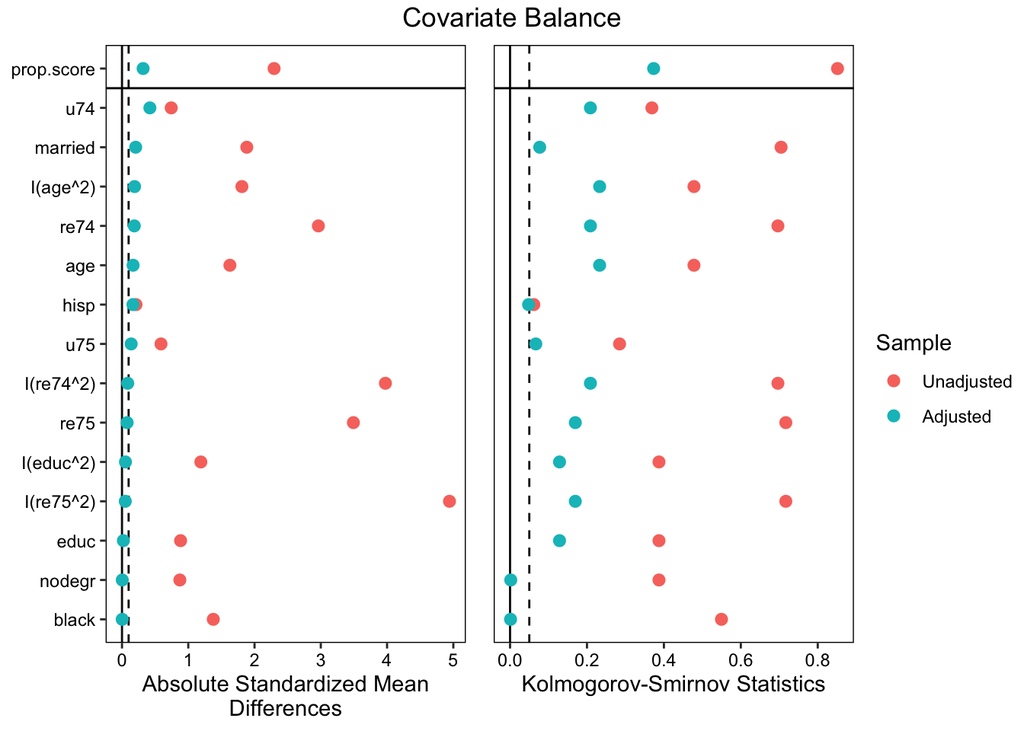

```r
# covariate balancing
love_plot(W1)
```

The ATT is 1.14. This means that on average, receiving the treatment caused an increase in income of 1.14 thousand dollars ($1,140). (Finally, we’re positive, our previous ATT estimates were negative).

However, looking at our covariate balancing, ASMDs are pretty far outside the range of accepted values, and especially so for the KSDs. I’d want to modify the propensity score model.